# Gastric Cancer - malignant ascites study

GSE228598 scRNA-seq Analysis Part 2 - CellChat

Aymen Maqsood

2026-02-19

## Setup

```r
##############################
###        SETUP           ###
##############################

# Loading required libraries
library(Seurat)
library(CellChat)
library(ggplot2)
library(dplyr)
library(patchwork)
set.seed(1)

# Loading merged object with compartment + Azimuth labels from Part 1
merged <- readRDS("data_processed/gse228598_harmony.rds")
```

## Cell Labels for CellChat

CellChat needs discrete groups, so collapsing Azimuth L2 subtypes into broader categories. Immune cells get Azimuth labels, non-immune keep their compartment name.

```r
##############################
###    CELL LABELS         ###
##############################

# Mapping Azimuth L2 subtypes to CellChat groups
# could do finer resolution here but 10 groups is enough for pathway-level analysis
label_map <- c(
  "CD14 Mono" = "CD14 Mono", "CD16 Mono" = "CD16 Mono",
  "cDC1" = "cDC", "cDC2" = "cDC", "pDC" = "cDC",
  "CD4 CTL" = "CD4 T", "CD4 Naive" = "CD4 T", "CD4 Proliferating" = "CD4 T",
  "CD4 TCM" = "CD4 T", "CD4 TEM" = "CD4 T", "Treg" = "CD4 T",
  "CD8 Naive" = "CD8 T", "CD8 Proliferating" = "CD8 T",
  "CD8 TCM" = "CD8 T", "CD8 TEM" = "CD8 T",
  "MAIT" = "CD8 T", "dnT" = "CD8 T", "gdT" = "CD8 T",
  "NK" = "NK", "NK Proliferating" = "NK", "NK_CD56bright" = "NK",
  "B intermediate" = "B cell", "B memory" = "B cell", "B naive" = "B cell",
  "Plasmablast" = "Plasma"
)

# Immune cells get labels from Azimuth, non-immune keep compartment name
immune <- subset(merged, compartment %in% c("Myeloid", "T/NK", "B cell", "Plasma"))
immune$cellchat_label <- unname(label_map[immune$azimuth_l2])

non_immune <- subset(merged, compartment %in% c("Epithelial", "Mesothelial"))
non_immune$cellchat_label <- non_immune$compartment

obj <- merge(immune, non_immune)
obj <- subset(obj, !is.na(cellchat_label))

table(obj$cellchat_label)
```

```
##
##      B cell   CD14 Mono   CD16 Mono       CD4 T       CD8 T         cDC
##        1379       21587        5365        6203        5185        3251
##  Epithelial Mesothelial          NK      Plasma
##        1562        1368         851         140
```

```r
rm(immune, non_immune, merged)
gc()
```

```
##             used   (Mb) gc trigger   (Mb) limit (Mb)   max used   (Mb)
## Ncells   5937224  317.1    9423210  503.3         NA    9423210  503.3
## Vcells 266536256 2033.6 1274980654 9727.4      16384 1248435992 9524.9
```

## CellChat Inference

Running CellChat with triMean – stricter than truncatedMean, so fewer false positives but might miss some weaker signals.

```r
##############################
###   CELLCHAT INFERENCE   ###
##############################

# triMean is more conservative, which seems appropriate for an exploratory analysis
# could try truncatedMean later to see if we're missing anything
obj <- JoinLayers(obj)
cellchat <- createCellChat(obj, group.by = "cellchat_label")
```

```
## [1] "Create a CellChat object from a Seurat object"
## The `data` slot in the default assay is used. The default assay is RNA
## The `meta.data` slot in the Seurat object is used as cell meta information
```

```
## Set cell identities for the new CellChat object
## The cell groups used for CellChat analysis are  B cell, CD14 Mono, CD16 Mono, CD4 T, CD8 T, cDC, Epithelial, Mesothelial, NK, Plasma
```

```r
CellChatDB <- CellChatDB.human
cellchat@DB <- CellChatDB

cellchat <- subsetData(cellchat)
cellchat <- identifyOverExpressedGenes(cellchat)
cellchat <- identifyOverExpressedInteractions(cellchat)
```

```
## The number of highly variable ligand-receptor pairs used for signaling inference is 1934
```

```r
cellchat <- computeCommunProb(cellchat, type = "triMean")
```

```
## triMean is used for calculating the average gene expression per cell group.
## [1] ">>> Run CellChat on sc/snRNA-seq data <<< [2026-02-20 15:46:30.266222]"
## [1] ">>> CellChat inference is done. Parameter values are stored in `object@options$parameter` <<< [2026-02-20 15:51:29.08769]"
```

```r
cellchat <- filterCommunication(cellchat, min.cells = 10)
cellchat <- computeCommunProbPathway(cellchat)
cellchat <- aggregateNet(cellchat)
cellchat <- netAnalysis_computeCentrality(cellchat)

saveRDS(cellchat, "data_processed/cellchat_object.rds")

rm(obj)
gc()
```

```
##            used  (Mb) gc trigger   (Mb) limit (Mb)   max used   (Mb)
## Ncells  6168128 329.5    9423210  503.3         NA    9423210  503.3
## Vcells 98180490 749.1 1019984524 7781.9      16384 1274980601 9727.4
```

## Communication Overview

[figure not shown]

```r
##############################
###   COMMUNICATION        ###
###   OVERVIEW             ###
##############################

par(mfrow = c(1, 2))
netVisual_circle(cellchat@net$count, vertex.weight = table(cellchat@idents),
                 vertex.label.cex = 0.7, edge.width.max = 10)
title("Number of interactions")
netVisual_circle(cellchat@net$weight, vertex.weight = table(cellchat@idents),
                 vertex.label.cex = 0.7, edge.width.max = 10)
title("Interaction strength")
```

## Signaling Pathway Ranking

Looking at all significant pathways ranked by information flow before picking out the immunosuppressive ones.

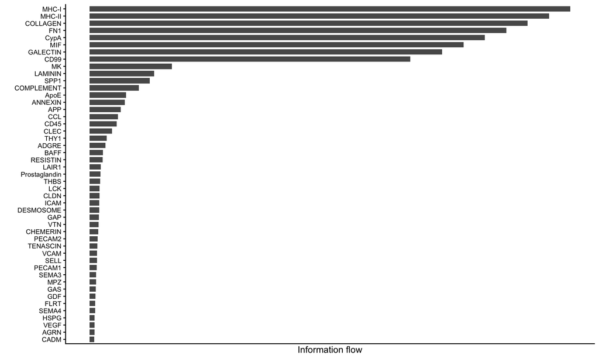

```r
##############################
###   PATHWAY RANKING      ###
##############################

# rankNet gives a nice overview of what's actually active
gg <- rankNet(cellchat, mode = "single", stacked = TRUE, do.stat = TRUE)
gg
```

```r
ggsave("figures/cellchat_pathway_ranking.png", gg, width = 10, height = 6)
```

```r
# what pathways actually made it through
cat("Total active pathways:", length(cellchat@netP$pathways), "\n")
```

```
## Total active pathways: 47
```

```r
cat(paste(cellchat@netP$pathways, collapse = ", "), "\n")
```

[output not shown]

## Immunosuppressive Pathway Networks

Focusing on six pathways tied to macrophage-mediated immunosuppression: MIF, SPP1, GALECTIN, COMPLEMENT, CCL, and FN1. FN1 is included because it’s one of the M2TS signature genes from Sullivan et al.

```r
##############################
###   IMMUNOSUPPRESSIVE    ###
###   PATHWAYS             ###
##############################

immuno_paths <- c("MIF", "SPP1", "GALECTIN", "COMPLEMENT", "CCL", "FN1")

# not all of these necessarily reach significance in every run
active_paths <- cellchat@netP$pathways
immuno_paths <- immuno_paths[immuno_paths %in% active_paths]
cat("Active immunosuppressive pathways:", paste(immuno_paths, collapse = ", "), "\n")
```

```
## Active immunosuppressive pathways: MIF, SPP1, GALECTIN, COMPLEMENT, CCL, FN1
```

```r
nr <- ceiling(length(immuno_paths) / 3)
par(mfrow = c(nr, 3))
for (p in immuno_paths) {
  netVisual_aggregate(cellchat, signaling = p, layout = "circle",
                      vertex.label.cex = 0.6, edge.width.max = 8)
  title(p)
}
```

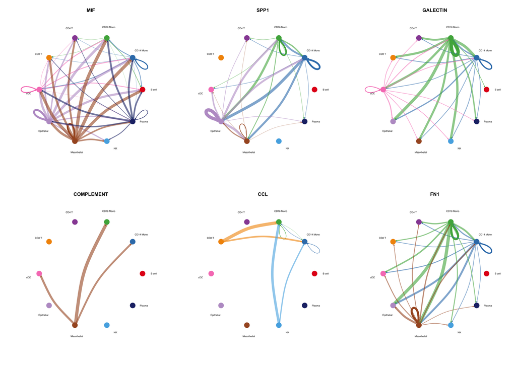

```r
png("figures/cellchat_immunosuppressive_networks.png", width = 14, height = 10, units = "in", res = 300)
par(mfrow = c(nr, 3))
for (p in immuno_paths) {
  netVisual_aggregate(cellchat, signaling = p, layout = "circle",
                      vertex.label.cex = 0.6, edge.width.max = 8)
  title(p)
}
dev.off()
```

## Sender-Receiver Heatmap

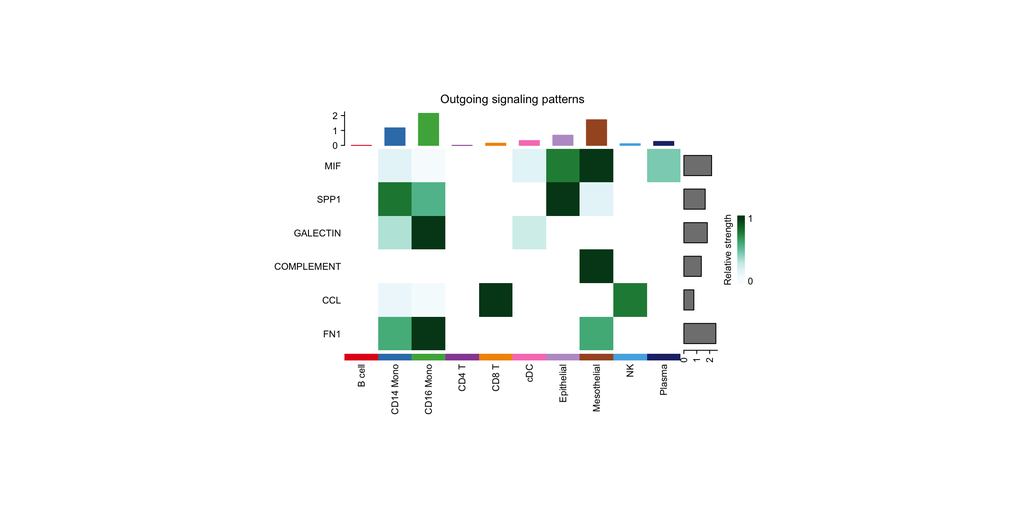

```r
##############################
###   SENDER-RECEIVER      ###
###   HEATMAP              ###
##############################

netAnalysis_signalingRole_heatmap(cellchat, signaling = immuno_paths, width = 10, height = 6)
```

The heatmap confirms the pattern – CD14/CD16 monocytes light up as senders for SPP1, GALECTIN, and FN1, while mesothelial cells are the main MIF and COMPLEMENT source. So you’ve got two separate compartments (myeloid and stromal) both pushing immunosuppression through different pathways. Whether that’s coordinated or just convergent isn’t clear from this data alone.

## Ligand-Receptor Interactions

Drilling into specific L-R pairs from myeloid and epithelial sources targeting immune effectors.

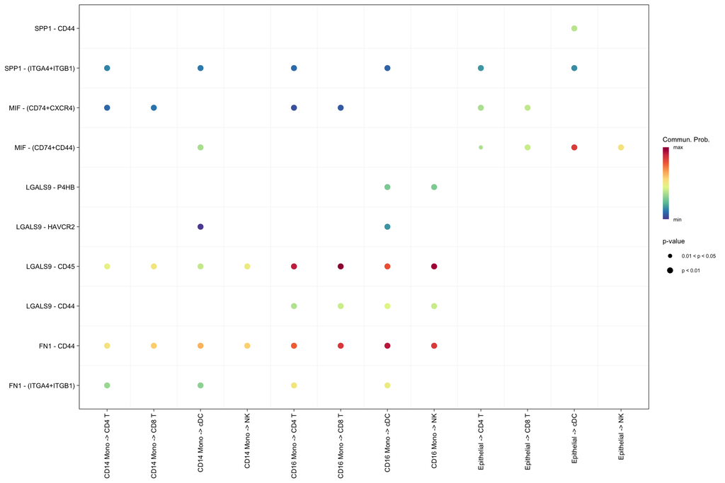

```r
##############################
###   LIGAND-RECEPTOR      ###
###   BUBBLE PLOT          ###
##############################

# sources: myeloid + epithelial; targets: lymphocytes + DCs
p <- netVisual_bubble(cellchat,
  sources.use = c("CD14 Mono", "CD16 Mono", "Epithelial"),
  targets.use = c("CD4 T", "CD8 T", "NK", "cDC"),
  signaling = immuno_paths,
  remove.isolate = TRUE)
p
```

```r
ggsave("figures/cellchat_bubble_immunosuppressive.png", p, width = 12, height = 8)
```

## Top Interactions by Probability

```r
##############################
###   TOP INTERACTIONS     ###
##############################

# TODO: might be worth looking at target-side only (just T cells) to see what
# they're receiving from all sources

df <- subsetCommunication(cellchat, signaling = immuno_paths)
write.csv(df, "tables/cellchat_immunosuppressive_interactions.csv", row.names = FALSE)
cat(nrow(df), "interactions exported\n")
```

```
## 207 interactions exported
```

```r
head(df[order(-df$prob), ], 15)
```

```
##          source      target ligand    receptor       prob pval interaction_name
## 194   CD16 Mono  Epithelial    FN1        CD44 0.19123285    0         FN1_CD44
## 182   CD16 Mono   CD16 Mono    FN1        CD44 0.12610804    0         FN1_CD44
## 195 Mesothelial  Epithelial    FN1        CD44 0.11843952    0         FN1_CD44
## 193   CD14 Mono  Epithelial    FN1        CD44 0.11677903    0         FN1_CD44
## 179   CD16 Mono   CD14 Mono    FN1        CD44 0.11555151    0         FN1_CD44
## 97  Mesothelial   CD16 Mono     C3 ITGAM_ITGB2 0.11472002    0   C3_ITGAM_ITGB2
## 94  Mesothelial   CD16 Mono     C3       C3AR1 0.10453517    0         C3_C3AR1
## 3         CD8 T   CD16 Mono   CCL5        CCR1 0.09668637    0        CCL5_CCR1
## 41  Mesothelial   CD16 Mono    MIF   CD74_CD44 0.08639192    0    MIF_CD74_CD44
## 36  Mesothelial   CD14 Mono    MIF   CD74_CD44 0.08602863    0    MIF_CD74_CD44
## 197   CD16 Mono Mesothelial    FN1        CD44 0.07965376    0         FN1_CD44
## 96  Mesothelial   CD14 Mono     C3 ITGAM_ITGB2 0.07784887    0   C3_ITGAM_ITGB2
## 50  Mesothelial         cDC    MIF   CD74_CD44 0.07780705    0    MIF_CD74_CD44
## 109   CD16 Mono       CD8 T LGALS9       PTPRC 0.07621155    0      LGALS9_CD45
```

[output cut: 33 more lines]

FN1->CD44 from monocytes and complement signaling (C3-related) from mesothelial cells dominate the top of the list. MIF from mesothelial cells to monocytes and cDCs is up there too. The overall picture is that the peritoneal stroma (mesothelial cells mainly) is feeding into myeloid-driven suppression – mesothelial cells recruit and activate monocytes via MIF and complement, and then monocytes do the heavy lifting of suppressing T cells through galectin and SPP1. Not sure if that’s a general ascites thing or specific to gastric cancer peritoneal metastasis.